# Relatório 05

Felipe Henrique

12/05/2025

# 1 Objetivo

Este trabalho tem como propósito avaliar um experimento conduzido sob o Delineamento em Blocos Casualizado (DBC), uma metodologia que organiza os tratamentos em blocos homogêneos com o objetivo de reduzir a variabilidade experimental e aumentar a precisão das comparações.

A abordagem inclui uma análise descritiva tanto global quanto por tratamento, considerando estatísticas como a média, o desvio padrão e o coeficiente de variação. Além disso, será construído um gráfico boxplot para facilitar a visualização dos dados. A análise será complementada com a aplicação da ANOVA, contemplando a formulação das hipóteses nula e alternativa, a apresentação da tabela de variância e a verificação das premissas do modelo por meio de gráficos de resíduos.

# 2 Desenvolvimento

```r
library(dplyr)
library(gt)

dados <- data.frame(
  Placa = rep(1:5, each = 4),
  Sistema = rep(c("Alumínio", "Ventilação", "HeatPipe", "Peltier"), 5),
  Temperatura.Final = c(78, 72, 69, 62,
                        80, 73, 70, 64,
                        79, 74, 68, 63,
                        77, 71, 67, 61,
                        81, 75, 69, 65)
)

# Exibir tabela formatada
dados |>
  gt() |>
  tab_style(
    style = list(cell_text(weight = "bold", color = "white"),
                 cell_fill(color = "black")),
    locations = cells_column_labels()
  ) |>
  tab_style(
    style = cell_text(align = "center"),
    locations = cells_body(columns = everything())
  ) |>
  data_color(
    columns = everything(),
    rows = 1:4,
    palette = "#f2f2f2"
  ) |>
  data_color(
    columns = everything(),
    rows = 5:8,
    palette = "lightgreen"
  ) |>
  data_color(
    columns = everything(),
    rows = 9:12,
    palette = "#f2f2f2"
  ) |>
  data_color(
    columns = everything(),
    rows = 13:16,
    palette = "lightgreen"
  ) |>
  data_color(
    columns = everything(),
    rows = 17:20,
    palette = "#f2f2f2"
  )
```

| Placa | Sistema | Temperatura.Final |
| --- | --- | --- |
| 1 | Alumínio | 78 |
| 1 | Ventilação | 72 |
| 1 | HeatPipe | 69 |
| 1 | Peltier | 62 |
| 2 | Alumínio | 80 |
| 2 | Ventilação | 73 |
| 2 | HeatPipe | 70 |
| 2 | Peltier | 64 |
| 3 | Alumínio | 79 |
| 3 | Ventilação | 74 |
| 3 | HeatPipe | 68 |
| 3 | Peltier | 63 |
| 4 | Alumínio | 77 |
| 4 | Ventilação | 71 |
| 4 | HeatPipe | 67 |
| 4 | Peltier | 61 |
| 5 | Alumínio | 81 |
| 5 | Ventilação | 75 |
| 5 | HeatPipe | 69 |
| 5 | Peltier | 65 |

## 2.1 Análise Descritiva

Para a Análise Descritiva, foram calculadas a média (X̄), o desvio padrão (S) e o coeficiente de variação (CV), a fim de caracterizar a variabilidade e o comportamento dos dados.

### 2.1.1 Análise Geral

Estes são os valores gerais de média = 70.9, Desvio Padrão = 6.172093 e Coeficiente de Variação = 8.705350.

```r
# Geral
media_geral <- mean(dados$Temperatura.Final)
dp_geral <- sd(dados$Temperatura.Final)
cv_geral <- (dp_geral / media_geral) * 100

tabela_estatisticas <- data.frame(
  Estatística = c("Média Geral", "Desvio Padrão Geral", "Coeficiente de Variação (%)"),
  Valor = c(media_geral, dp_geral, cv_geral)
)

tabela_estatisticas |>
  gt() |>
  tab_style(
    style = list(cell_text(weight = "bold", color = "white"),
                 cell_fill(color = "black")),
    locations = cells_column_labels()
  ) |>
  tab_style(
    style = cell_text(align = "center"),
    locations = cells_body(columns = everything())
  ) |>
  data_color(
    columns = everything(),
    rows = 1,
    palette = "#f2f2f2"
  ) |>
  data_color(
    columns = everything(),
    rows = 2,
    palette = "#f2f2f2"
  ) |>
  data_color(
    columns = everything(),
    rows = 3,
    palette = "#f2f2f2"
  )
```

| Estatística | Valor |
| --- | --- |
| Média Geral | 70.900000 |
| Desvio Padrão Geral | 6.172093 |
| Coeficiente de Variação (%) | 8.705350 |

### 2.1.2 Análise por Tratamento

Agora, é possível ver a Média, o Desvio Padrão e o Coeficiente de Variância de cada tipo de dissipador de calor.

```r
# Por Tratamento
descr_trat <- dados %>%
  group_by(Sistema) %>%
  summarise(
    Média = round(mean(Temperatura.Final), 3),
    Desvio_Padrão = round(sd(Temperatura.Final), 3),
    CV = round((sd(Temperatura.Final) / mean(Temperatura.Final)) * 100, 3)
  )


descr_trat |>
  gt() |>
  tab_style(
    style = list(cell_text(weight = "bold", color = "white"),
                 cell_fill(color = "black")),
    locations = cells_column_labels()
  ) |>
  tab_style(
    style = cell_text(align = "center"),
    locations = cells_body(columns = everything())
  ) |>
  data_color(
    columns = everything(),
    rows = 1,
    palette = "#f2f2f2"
  ) |>
  data_color(
    columns = everything(),
    rows = 2,
    palette = "#f2f2f2"
  ) |>
  data_color(
    columns = everything(),
    rows = 3,
    palette = "#f2f2f2"
  )|>
  data_color(
    columns = everything(),
    rows = 4,
    palette = "#f2f2f2"
  )
```

| Sistema | Média | Desvio_Padrão | CV |
| --- | --- | --- | --- |
| Alumínio | 79.0 | 1.581 | 2.001 |
| HeatPipe | 68.6 | 1.140 | 1.662 |
| Peltier | 63.0 | 1.581 | 2.510 |
| Ventilação | 73.0 | 1.581 | 2.166 |

### 2.1.3 Boxplot

O boxplot apresentado abaixo compara a temperatura final alcançada por quatro sistemas de resfriamento (Alumínio, HeatPipe, Peltier e Ventilação) após 30 minutos de operação contínua. Observa-se que o sistema Peltier apresentou a menor mediana de temperatura, indicando o melhor desempenho na dissipação térmica entre os sistemas avaliados. Em contraste, o sistema de Alumínio teve a maior mediana, evidenciando menor eficiência.

A separação clara entre as caixas dos diferentes sistemas sugere que há diferenças significativas no desempenho térmico entre eles, o que será confirmado posteriormente com a análise de variância (ANOVA). Em síntese, os resultados visuais indicam que o sistema Peltier é o mais eficaz na redução da temperatura, enquanto o sistema de Alumínio é o menos eficiente.

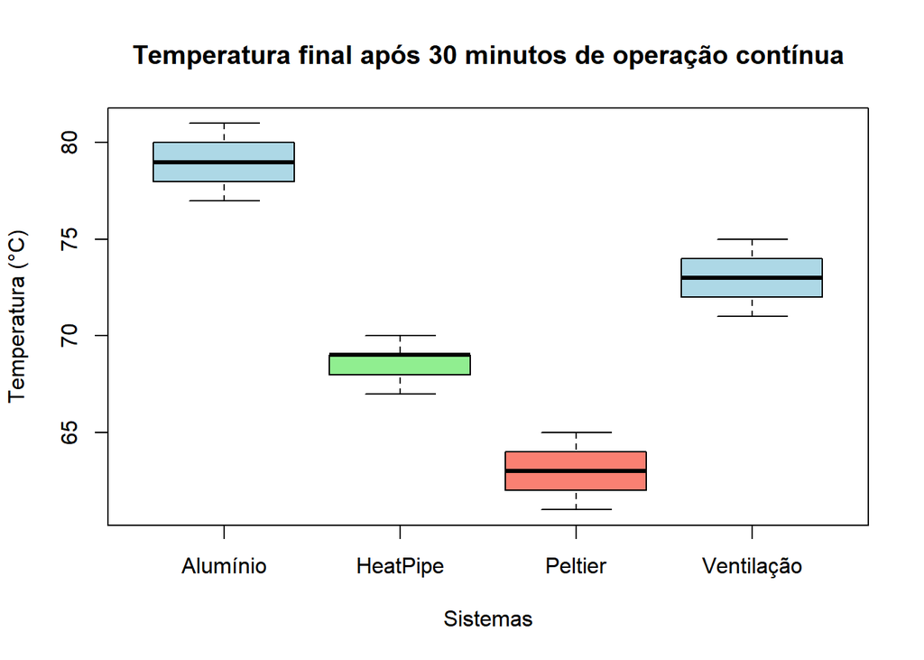

```r
# 3. Boxplot dos tratamentos

boxplot(Temperatura.Final ~ Sistema, data = dados,
        col = c("lightblue", "lightgreen", "salmon"),
        main = "Temperatura final após 30 minutos de operação contínua",
        ylab = "Temperatura (°C)", xlab = "Sistemas")
```